# Series de tiempo

Sol Represa

26 de abril de 2018

Una serie tiempo es una secuencia de observaciones, medidos en determinados momentos del tiempo, ordenados cronológicamente y, espaciados entre sí de manera uniforme, así los datos usualmente son dependientes entre sí. Su análisis se utiliza en gran medida para realizar predicciones.

## Componentes de una serie temporal

El análisis clásico de las series temporales se basa en la suposición de que los valores que toma la variable de observación es la consecuencia de tres componentes, cuya actuación conjunta da como resultado los valores medidos, estos componentes son:

- **Componente tendencia**.- Se puede definir como un cambio a largo plazo que se produce en la relación al nivel medio, o el cambio a largo plazo de la media. La tendencia se identifica con un movimiento suave de la serie a largo plazo.
- **Componente estacional**.- Muchas series temporales presentan cierta periodicidad o dicho de otro modo, variación de cierto período (semestral, mensual, etc.). Por ejemplo las Ventas al Detalle en Puerto Rico aumentan por los meses de noviembre y diciembre por las festividades navideñas. Estos efectos son fáciles de entender y se pueden medir explícitamente o incluso se pueden eliminar de la serie de datos, a este proceso se le llama desestacionalización de la serie.
- **Componente aleatoria**.- Esta componente no responde a ningún patrón de comportamiento, sino que es el resultado de factores fortuitos o aleatorios que inciden de forma aislada en una serie de tiempo.

## Método Box-Jenkins

Box-Jenkins refers to the entire approach of analysis of Time series that is.

1. Analisis de estacionariedad (Test Dickey-Fuller)
2. Selección del modelo (AFC, PACF, Box Ljung test)
3. Estimación de parámetros
4. Análsisi de los residuos estandar (should be indipendent)

### Analisis de estacionariedad

Una serie es estacionaria cuando es estable a lo largo del tiempo, es decir, cuando la media y varianza son constantes en el tiempo. Esto se refleja gráficamente en que los valores de la serie tienden a oscilar alrededor de una media constante y la variabilidad con respecto a esa media también permanece constante en el tiempo.

Para el análisis de estacionariedad utilizamos el Test Dickey-Fuller. Podemos evaluar también si los datos presentan un comportamiento explosivo.

```r
# Test Dickey-Fuller
adf.test(y, alternative = "stationary", k=0) # p<0.05 es estacionario
```

```
##
##  Augmented Dickey-Fuller Test
##
## data:  y
## Dickey-Fuller = -15.409, Lag order = 0, p-value = 0.01
## alternative hypothesis: stationary
```

```r
adf.test(y, alternative = "explosive", k=0) # p>0.05 no es explosivo, es estacionario
```

```
##
##  Augmented Dickey-Fuller Test
##
## data:  y
## Dickey-Fuller = -15.409, Lag order = 0, p-value = 0.99
## alternative hypothesis: explosive
```

### Identificación del modelo

#### Ruido blanco (“white noise”)

Un ruido blanco es un caso simple de los procesos estocásticos, donde los valores son independientes e idénticamente distribuidos a lo largo del tiempo con media cero e igual varianza, se denota por $\epsilon_t$.

$$\epsilon_t\sim N(0,\sigma²)$$
$$cov(\epsilon_{t_i},\epsilon_{t_j}= 0)$$
$$\forall t_i \neq t_j$$

#### Autocorrelación

En ocasiones en una serie de tiempo acontece, que los valores que toma una variable en el tiempo no son independientes entre sí, sino que un valor determinado depende de los valores anteriores, existen dos formas de medir esta dependencia de las variables.

##### *Función de Autocorrelación (ACF)*

La autocorrelación mide la correlación entre dos variables separadas por k periodos.

$$\rho_j=corr(X_j, X_{j-k})=\frac{cov(X_j, X_{j-k})}{\sqrt{var(X_j)}\sqrt{var(X_{j-k})}}$$
La función de autocorrelación simple tiene las siguientes propiedades:

$$\rho_0 = 1$$
$$-1 \leq \rho \leq 1$$
$$\rho_j = \rho_{-j}$$

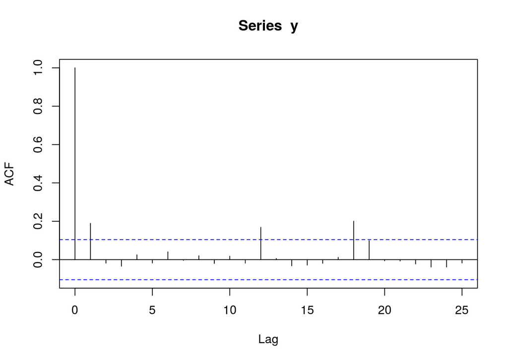

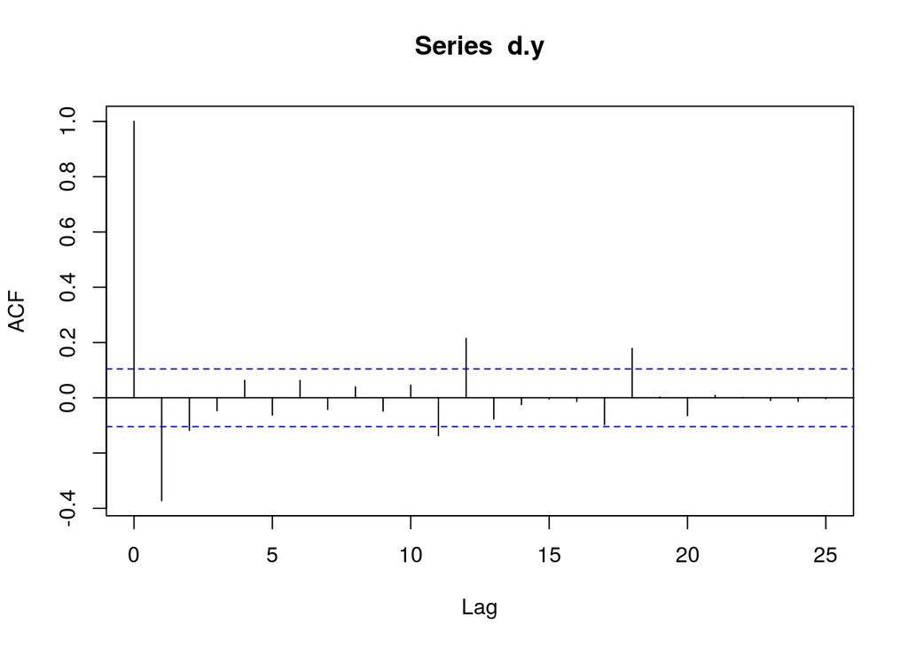

##### *Función de Autocorrelación Parcial (PACF)*

La autocorrelación parcial mide la correlación entre dos variables separadas por k periodos cuando no se considera la dependencia creada por los retardos intermedios existentes entre ambas.

$$\pi_j = \frac{cov(X_j-\hat{X}_j, X_{j-k}-\hat{X}_{j-k})}{\sqrt{var(X_j-\hat{X}_j)}\sqrt{var(X_{j-k}-\hat{X}_{j-k})}}$$

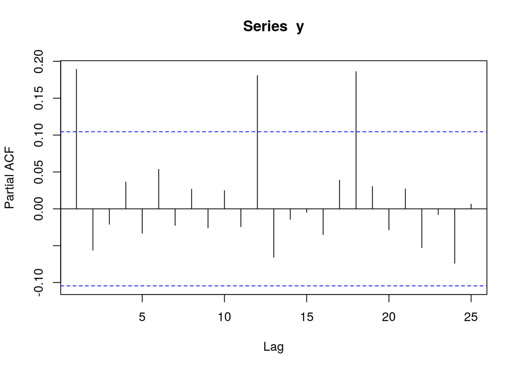

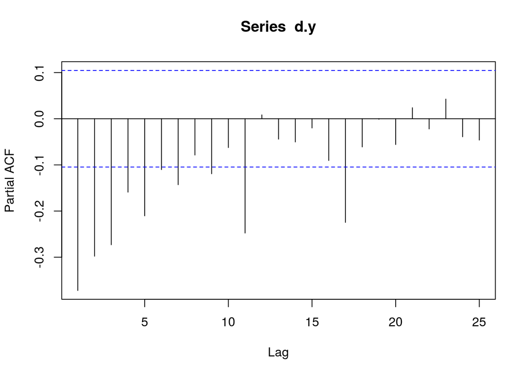

##### *Prueba de Ljung-Box*

Esta prueba permite probar en forma conjunta de que todos los coeficientes de autocorrelación son simultáneamente iguales a cero, esto es que son independientes, está definida como

$$LB = n(n+2) \sum_{k=1}^m(\frac{\hat{\rho}_k²}{n-k} \sim \chi_{(m)}^2)$$
donde *n* es el tamaño de la muestra y *m* la longitud del rezago.

**Ho**: Las autocorrelaciones son independientes.

**Ha**: Las autocorrelaciones no son independientes.

En una aplicación, si el *Q* calculada excede el valor *Q* crítico de la tabla $\chi^2$ cuadrada al nivel de significancia seleccionado, no se acepta la hipótesis nula de que todos los coeficientes de autocorrelación son iguales a cero; por lo menos algunos de ellos deben ser diferentes de cero.

```r
Box.test(y,lag=2,type="Ljung-Box") #check autocorrelation
```

```
##
##  Box-Ljung test
##
## data:  y
## X-squared = 12.816, df = 2, p-value = 0.001648
```

```r
#auto.arfima(y) #perform lot of precedeing task automatically
```